# Seaflow Cytometry

```r
suppressMessages(library(caret))
suppressMessages(library(rpart))
suppressMessages(library(tree))
suppressMessages(library(randomForest))
suppressMessages(library(e1071))
suppressMessages(library(ggplot2))
suppressMessages(library(dplyr))
suppressMessages(library(rattle))
```

In this project, we will be working with data from the SeaFlow environmental Seaflow Cytometry instrument.

A flow cytometer delivers a flow of particles through capilliary. By shining lasers of different wavelengths and measuring the absorption and refraction patterns, you can determine how large the particle is and some information about its color and other properties, allowing you to detect it.

The technology was developed for medical applciations, where the particles were potential pathogens in, say, serum, and the goal was to give a diagnosis. But the technology was adapted for use in environmental science to understand microbial population profiles.

The SeaFlow instrument, developed by the Armbrust Lab at the University of Washington, is unique in that it is deployed on research vessels and takes continuous measurements of population profiles in the open ocean.

The scale of the data can be quite large, and is expected to grow significantly: A two-week cruise from one vessel can generate hundreds of gigabytes per day, and the vision is to deploy one of these instruments on not only research vessels but the commercial shipping fleet as well.

While there are a number of challenging analytics tasks associated with this data, a central task is classification of particles. Based on the optical measurements of the particle, it can be identified as one of several populations.

Dataset

We use a dataset that represents a 21 minute sample from the vessel in a file seaFlow 21min.csv. This sample has been pre-processed to remove the calibration “beads” that are passed through the system for monitoring, as well as some other particle types.

The columns of this dataset are as follows:

· file_id: The data arrives in files, where each file represents a three-minute window; this field represents which file the data came from. The number is ordered by time, but is otherwise not significant.

· time: This is an integer representing the time the particle passed through the instrument. Many particles may arrive at the same time; time is not a key for this relation.

· cell_id: A unique identifier for each cell WITHIN a file. (file_id, cell_id) is a key for this relation.

· d1, d2: Intensity of light at the two main sensors, oriented perpendicularly. These sensors are primarily used to determine whether the particles are properly centered in the stream. Used primarily in preprocesssing; they are unlikely to be useful for classification.

· fsc_small, fsc_perp, fsc_big: Forward scatter small, perpendicular, and big. These values help distingish different sizes of particles.

· pe: A measurement of phycoerythrin fluorescence, which is related to the wavelength associated with an orange color in microorganisms

· chl_small, chl_big: Measurements related to the wavelength of light corresponding to chlorophyll.

· pop: This is the class label assigned by the clustering mechanism used in the production system. It can be considered “ground truth”“, but there are particles that cannot be unambiguously classified, so we should not aim for 100% accuracy. The values in this column are crypto, nano, pico, synecho, and ultra

## Step 1: Read and summarize the data

Read the file seaFlow 21min.csv and get the overall counts for each category of particle.

```r
data <- read.csv("seaFlow 21min.csv")
data %>% select(pop) %>% table
```

```
## .
##  crypto    nano    pico synecho   ultra
##     102   12698   20860   18146   20537
```

## Step 2: Split the data into test and training sets

We divide the data into two equal subsets, one for training and one for testing.

```r
indices <- createDataPartition(y=data$pop, p=0.5, list = FALSE)
Train <- data[indices, ]
Validation <- data[-indices, ]
```

## Step 3: Exploratory Analysis

We plot pe against chl_small and color by pop. The plot is interesting because we notice that there is obvious clustering in the data set.

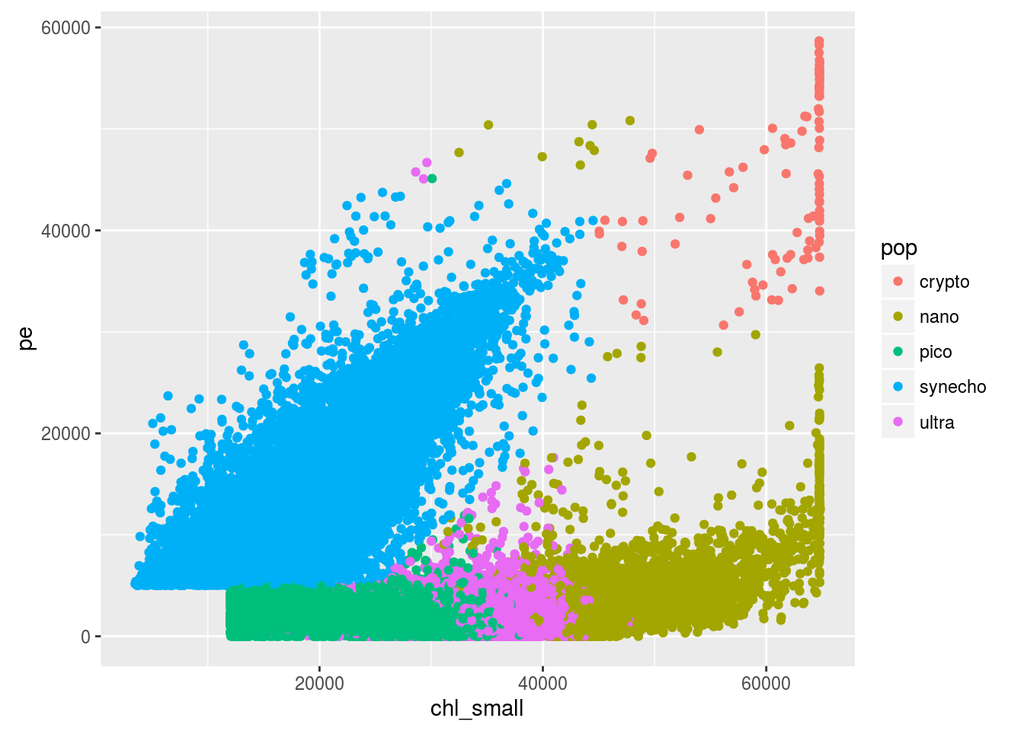

```r
ggplot(data, aes(chl_small, pe, color = pop)) + geom_point(na.rm = TRUE)
```

## Step 4: Train a decision tree.

We train models of the form:

`model <- train(formula, dataframe)`

We then use the model object to make predictions by passing it to the predict function.

A formula object describes the relationship between the independent variables and the response variable, and can be expressed with the syntax

`pop ~ fsc_small + fsc_perp + fsc_big + pe + chl_big + chl_small`

and used with the formula function to construct the formula object itself:

`fol <- formula(pop ~ fsc_small + fsc_perp + fsc_big + pe + chl_big + chl_small)`

The rpart library uses this convention. With training data `Train` and formula object called `fol`, we construct a decision tree. Here we have used `fancyRpartPlot` from the rattle plot to visulize our decision tree.

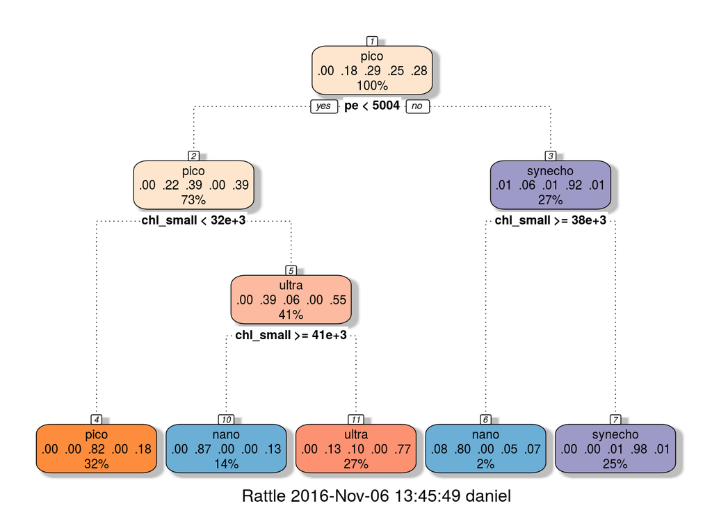

```r
fol <- formula(pop ~ fsc_small + fsc_perp + fsc_big + pe + chl_big + chl_small)
tree_model <- rpart(fol, method="class", data=Train)
fancyRpartPlot(tree_model)
```

We are also interested in the accuracy of our tree.

```r
prediction_tree <- predict(tree_model, Validation, type = "class")
mean(prediction_tree == Validation$pop)
```

```
## [1] 0.8562384
```

We can also get a list of summary statistics by using `confusionMatrix`.

```r
confusionMatrix(prediction_tree, Validation$pop)
```

```
## $positive
## NULL
##
## $table
##           Reference
## Prediction crypto nano pico synecho ultra
##    crypto       0    0    0       0     0
##    nano        51 5024    1      39   709
##    pico         0    3 9517       1  2044
##    synecho      0   16   38    9033   118
##    ultra        0 1306  874       0  7397
##
## $overall
##       Accuracy          Kappa  AccuracyLower  AccuracyUpper   AccuracyNull
##      0.8562384      0.8058711      0.8525804      0.8598392      0.2883525
## AccuracyPValue  McnemarPValue
##      0.0000000            NaN
##
## $byClass
##                Sensitivity Specificity Pos Pred Value Neg Pred Value
## Class: crypto    0.0000000   1.0000000            NaN      0.9985900
## Class: nano      0.7913057   0.9731742      0.8626374      0.9563384
## Class: pico      0.9124640   0.9204382      0.8229140      0.9628952
## Class: synecho   0.9955913   0.9936527      0.9813145      0.9985167
## Class: ultra     0.7203935   0.9158399      0.7723713      0.8920433
##                Precision    Recall        F1  Prevalence Detection Rate
## Class: crypto         NA 0.0000000        NA 0.001409969      0.0000000
## Class: nano    0.8626374 0.7913057 0.8254333 0.175527356      0.1388958
## Class: pico    0.8229140 0.9124640 0.8653785 0.288352548      0.2631113
## Class: synecho 0.9813145 0.9955913 0.9884014 0.250836305      0.2497304
## Class: ultra   0.7723713 0.7203935 0.7454775 0.283873822      0.2045008
##                Detection Prevalence Balanced Accuracy
## Class: crypto             0.0000000         0.5000000
## Class: nano               0.1610130         0.8822399
## Class: pico               0.3197313         0.9164511
## Class: synecho            0.2544856         0.9946220
## Class: ultra              0.2647701         0.8181167
##
## $mode
## [1] "sens_spec"
##
## $dots
## list()
##
## attr(,"class")
## [1] "confusionMatrix"
```

## Step 5: Build and evaluate a random forest.

```r
forests_model <- randomForest(fol, data=Train)

prediction_forest <- predict(forests_model, Validation, type = "class")

confusionMatrix(prediction_forest, Validation$pop)
```

```
## $positive
## NULL
##
## $table
##           Reference
## Prediction crypto  nano  pico synecho ultra
##    crypto      48     2     0       1     0
##    nano         2  5558     0       3   318
##    pico         0     0 10102       1  1355
##    synecho      1     0     9    9067     8
##    ultra        0   789   319       1  8587
##
## $overall
##       Accuracy          Kappa  AccuracyLower  AccuracyUpper   AccuracyNull
##      0.9223411      0.8951999      0.9195351      0.9250790      0.2883525
## AccuracyPValue  McnemarPValue
##      0.0000000            NaN
##
## $byClass
##                Sensitivity Specificity Pos Pred Value Neg Pred Value
## Class: crypto    0.9411765   0.9999169      0.9411765      0.9999169
## Class: nano      0.8754135   0.9891691      0.9450774      0.9738858
## Class: pico      0.9685523   0.9473214      0.8816547      0.9867276
## Class: synecho   0.9993387   0.9993357      0.9980187      0.9997785
## Class: ultra     0.8362875   0.9571864      0.8856229      0.9365061
##                Precision    Recall        F1  Prevalence Detection Rate
## Class: crypto  0.9411765 0.9411765 0.9411765 0.001409969     0.00132703
## Class: nano    0.9450774 0.8754135 0.9089125 0.175527356     0.15365901
## Class: pico    0.8816547 0.9685523 0.9230629 0.288352548     0.27928451
## Class: synecho 0.9980187 0.9993387 0.9986783 0.250836305     0.25067043
## Class: ultra   0.8856229 0.8362875 0.8602484 0.283873822     0.23740013
##                Detection Prevalence Balanced Accuracy
## Class: crypto           0.001409969         0.9705467
## Class: nano             0.162588814         0.9322913
## Class: pico             0.316773106         0.9579368
## Class: synecho          0.251168063         0.9993372
## Class: ultra            0.268060048         0.8967370
##
## $mode
## [1] "sens_spec"
##
## $dots
## list()
##
## attr(,"class")
## [1] "confusionMatrix"
```

Random forests are wonderful general purpose tools for classification. Their upside is that they are very accurate and can model interactions between variables, with the downsides being that they take a long time to train and are hard to interpret.

Random forests can automatically generate an estimate of variable importance during training by permuting the values in a given variable and measuring the effect on classification. If scrambling the values has little effect on the model’s ability to make predictions, then the variable must not be very important.

A random forest can obtain another estimate of variable importance based on the Gini impurity. Gini impurity is a proxy for the entropy of a system that we would like to be able model to produce predictions. The function `importance(model)` prints the mean decrease in gini importance for each variable. The higher the number, the more the gini impurity score decreases by branching on this variable, indicating that the variable is more important.

```r
forests_importance <- data.frame(importance(forests_model))

forests_importance$particle_type <- rownames(forests_importance)

forests_importance%>% arrange(desc(MeanDecreaseGini))
```

```
##   MeanDecreaseGini particle_type
## 1        8878.4769            pe
## 2        8020.9342     chl_small
## 3        4912.2123       chl_big
## 4        2769.4299     fsc_small
## 5        2067.9583      fsc_perp
## 6         204.4648       fsc_big
```

## Step 6: Train a support vector machine model and compare results.

Using the e1071 library, we train a support vector machine and compare to our other two approaches.

```r
svm_model <- svm(fol, data=Train)

prediction_svm <- predict(svm_model, Validation, type = "class")

confusionMatrix(prediction_svm, Validation$pop)
```

```
## $positive
## NULL
##
## $table
##           Reference
## Prediction crypto  nano  pico synecho ultra
##    crypto      46     1     0       1     0
##    nano         3  5626     0       2   360
##    pico         0     0 10060      30  1355
##    synecho      2     1    56    9031     4
##    ultra        0   721   314       9  8549
##
## $overall
##       Accuracy          Kappa  AccuracyLower  AccuracyUpper   AccuracyNull
##      0.9209588      0.8933800      0.9181306      0.9237192      0.2883525
## AccuracyPValue  McnemarPValue
##      0.0000000            NaN
##
## $byClass
##                Sensitivity Specificity Pos Pred Value Neg Pred Value
## Class: crypto    0.9019608   0.9999446      0.9583333      0.9998616
## Class: nano      0.8861238   0.9877607      0.9390753      0.9760437
## Class: pico      0.9645254   0.9461948      0.8789865      0.9850360
## Class: synecho   0.9953709   0.9976751      0.9930724      0.9984489
## Class: ultra     0.8325867   0.9596958      0.8911706      0.9353224
##                Precision    Recall        F1  Prevalence Detection Rate
## Class: crypto  0.9583333 0.9019608 0.9292929 0.001409969    0.001271737
## Class: nano    0.9390753 0.8861238 0.9118314 0.175527356    0.155538968
## Class: pico    0.8789865 0.9645254 0.9197714 0.288352548    0.278123358
## Class: synecho 0.9930724 0.9953709 0.9942203 0.250836305    0.249675154
## Class: ultra   0.8911706 0.8325867 0.8608831 0.283873822    0.236349562
##                Detection Prevalence Balanced Accuracy
## Class: crypto            0.00132703         0.9509527
## Class: nano              0.16562992         0.9369423
## Class: pico              0.31641370         0.9553601
## Class: synecho           0.25141688         0.9965230
## Class: ultra             0.26521246         0.8961412
##
## $mode
## [1] "sens_spec"
##
## $dots
## list()
##
## attr(,"class")
## [1] "confusionMatrix"
```

Directly comparing the accuracy of the three methods, we find that random forests is the most accurate, with svm not far behind.

```r
mean(prediction_tree == Validation$pop)
```

```
## [1] 0.8562384
```

```r
mean(prediction_forest == Validation$pop)
```

```
## [1] 0.9223411
```

```r
mean(prediction_svm == Validation$pop)
```

```
## [1] 0.9209588
```

## Step 7: Sanity check the data

Data scientists should never trust the data. There is no such thing as clean data. We should always be trying to prove our results wrong by finding problems with the data. Richard Feynman calls it “bending over backwards to show how you’re maybe wrong.” This is even more critical in data science, because almost by definition we are using someone else’s data that was collected for some other purpose rather than the experiment we want to do. So of course it’s going to have problems.

The measurements in this dataset are all supposed to be continuous `fsc_small, fsc_perp, fsc_big, pe, chl_small, chl_big`, but one is not.

There is another subtle issue with data as well. If we plot `time` vs. `chl_big`, we note a band of the data that looks out of place.

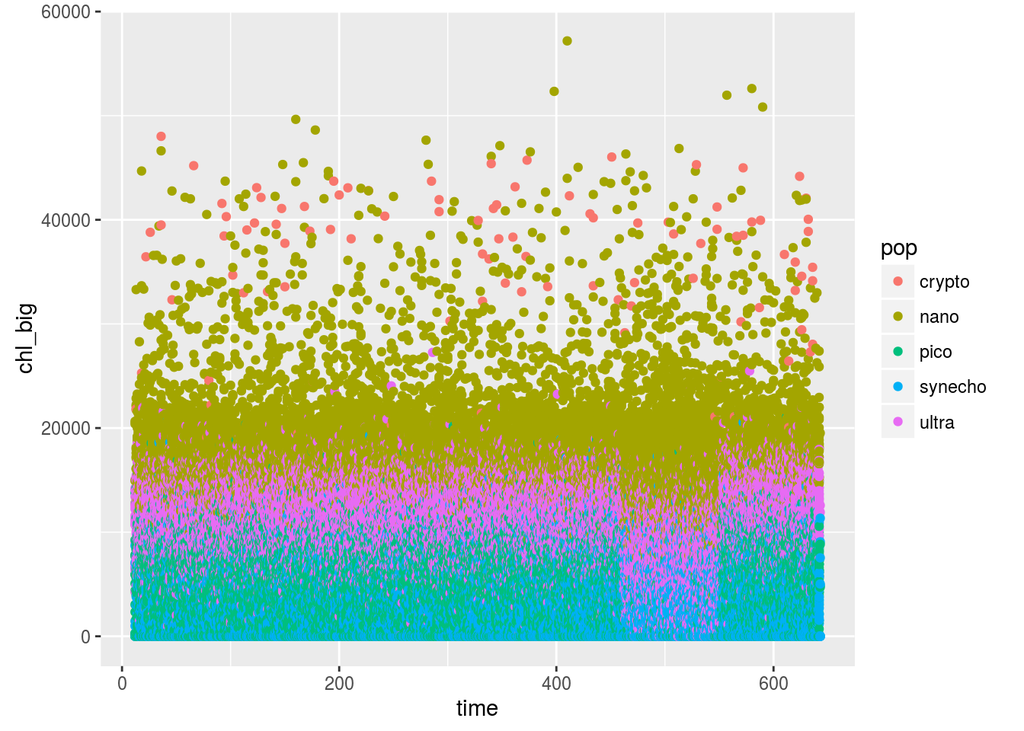

```r
ggplot(data, aes(time, chl_big, color = pop)) + geom_point(na.rm = TRUE)
```

This band corresponds to data from a particular file for which the sensor may have been miscalibrated. Removing this data from the dataset by filtering out all data associated with file_id 208 and repeating the experiment for all three methods, we find that our classifiers now have increased accuracy.

```r
filtered_data <- data %>% filter(file_id != 208)

indices <- createDataPartition(y=filtered_data$pop, p=0.5, list = FALSE)
Train <- filtered_data[indices, ]
Validation <- filtered_data[-indices, ]

tree_model <- rpart(fol, method="class", data=Train)

prediction_tree <- predict(tree_model, Validation, type = "class")

forests_model <- randomForest(fol, data=Train)

prediction_forest <- predict(forests_model, Validation, type = "class")

forests_importance$particle_type <- rownames(forests_importance)

forests_importance$particle_type <- rownames(forests_importance)

svm_model <- svm(fol, data=Train)

prediction_svm <- predict(svm_model, Validation, type = "class")

confusionMatrix(prediction_tree, Validation$pop)
```

```
## $positive
## NULL
##
## $table
##           Reference
## Prediction crypto nano pico synecho ultra
##    crypto       0    0    0       0     0
##    nano        43 4131    0      39   681
##    pico         0    0 9235       2   995
##    synecho      0    8   40    7083    87
##    ultra        0  645  689       0  6495
##
## $overall
##       Accuracy          Kappa  AccuracyLower  AccuracyUpper   AccuracyNull
##      0.8929838      0.8543608      0.8894412      0.8964505      0.3302290
## AccuracyPValue  McnemarPValue
##      0.0000000            NaN
##
## $byClass
##                Sensitivity Specificity Pos Pred Value Neg Pred Value
## Class: crypto    0.0000000   1.0000000            NaN      0.9985749
## Class: nano      0.8635033   0.9699476      0.8440948      0.9741683
## Class: pico      0.9268366   0.9506655      0.9025606      0.9634422
## Class: synecho   0.9942448   0.9941429      0.9812968      0.9982139
## Class: ultra     0.7865101   0.9391285      0.8296079      0.9210974
##                Precision    Recall        F1  Prevalence Detection Rate
## Class: crypto         NA 0.0000000        NA 0.001425115      0.0000000
## Class: nano    0.8440948 0.8635033 0.8536888 0.158552348      0.1369105
## Class: pico    0.9025606 0.9268366 0.9145375 0.330229013      0.3060683
## Class: synecho 0.9812968 0.9942448 0.9877284 0.236105127      0.2347463
## Class: ultra   0.8296079 0.7865101 0.8074843 0.273688397      0.2152587
##                Detection Prevalence Balanced Accuracy
## Class: crypto             0.0000000         0.5000000
## Class: nano               0.1621980         0.9167255
## Class: pico               0.3391111         0.9387511
## Class: synecho            0.2392205         0.9941939
## Class: ultra              0.2594704         0.8628193
##
## $mode
## [1] "sens_spec"
##
## $dots
## list()
##
## attr(,"class")
## [1] "confusionMatrix"
```

```r
confusionMatrix(prediction_forest, Validation$pop)
```

```
## $positive
## NULL
##
## $table
##           Reference
## Prediction crypto nano pico synecho ultra
##    crypto      42    0    0       0     0
##    nano         1 4557    0       3   239
##    pico         0    0 9722       0   209
##    synecho      0    4    9    7121     4
##    ultra        0  223  233       0  7806
##
## $overall
##       Accuracy          Kappa  AccuracyLower  AccuracyUpper   AccuracyNull
##      0.9693435      0.9583068      0.9673360      0.9712598      0.3302290
## AccuracyPValue  McnemarPValue
##      0.0000000            NaN
##
## $byClass
##                Sensitivity Specificity Pos Pred Value Neg Pred Value
## Class: crypto    0.9767442   1.0000000      1.0000000      0.9999668
## Class: nano      0.9525502   0.9904289      0.9493750      0.9910535
## Class: pico      0.9757126   0.9896581      0.9789548      0.9880447
## Class: synecho   0.9995789   0.9992624      0.9976184      0.9998698
## Class: ultra     0.9452652   0.9791923      0.9448076      0.9793711
##                Precision    Recall        F1  Prevalence Detection Rate
## Class: crypto  1.0000000 0.9767442 0.9882353 0.001425115    0.001391973
## Class: nano    0.9493750 0.9525502 0.9509599 0.158552348    0.151029066
## Class: pico    0.9789548 0.9757126 0.9773310 0.330229013    0.322208597
## Class: synecho 0.9976184 0.9995789 0.9985977 0.236105127    0.236005700
## Class: ultra   0.9448076 0.9452652 0.9450363 0.273688397    0.258708117
##                Detection Prevalence Balanced Accuracy
## Class: crypto           0.001391973         0.9883721
## Class: nano             0.159082624         0.9714895
## Class: pico             0.329135320         0.9826853
## Class: synecho          0.236569118         0.9994207
## Class: ultra            0.273820966         0.9622288
##
## $mode
## [1] "sens_spec"
##
## $dots
## list()
##
## attr(,"class")
## [1] "confusionMatrix"
```

```r
forests_importance%>% arrange(desc(MeanDecreaseGini))
```

```
##   MeanDecreaseGini particle_type
## 1        8878.4769            pe
## 2        8020.9342     chl_small
## 3        4912.2123       chl_big
## 4        2769.4299     fsc_small
## 5        2067.9583      fsc_perp
## 6         204.4648       fsc_big
```

```r
confusionMatrix(prediction_svm, Validation$pop)
```

```
## $positive
## NULL
##
## $table
##           Reference
## Prediction crypto nano pico synecho ultra
##    crypto      39    1    0       0     0
##    nano         1 4594    0       3   215
##    pico         0    0 9716      29   183
##    synecho      3    4   62    7090     3
##    ultra        0  185  186       2  7857
##
## $overall
##       Accuracy          Kappa  AccuracyLower  AccuracyUpper   AccuracyNull
##      0.9709343      0.9604739      0.9689763      0.9728009      0.3302290
## AccuracyPValue  McnemarPValue
##      0.0000000            NaN
##
## $byClass
##                Sensitivity Specificity Pos Pred Value Neg Pred Value
## Class: crypto    0.9069767   0.9999668      0.9750000      0.9998673
## Class: nano      0.9602843   0.9913742      0.9544982      0.9925079
## Class: pico      0.9751104   0.9895096      0.9786463      0.9877501
## Class: synecho   0.9952274   0.9968762      0.9899469      0.9985224
## Class: ultra     0.9514410   0.9829797      0.9546780      0.9817254
##                Precision    Recall        F1  Prevalence Detection Rate
## Class: crypto  0.9750000 0.9069767 0.9397590 0.001425115    0.001292546
## Class: nano    0.9544982 0.9602843 0.9573825 0.158552348    0.152255328
## Class: pico    0.9786463 0.9751104 0.9768751 0.330229013    0.322009744
## Class: synecho 0.9899469 0.9952274 0.9925801 0.236105127    0.234978292
## Class: ultra   0.9546780 0.9514410 0.9530568 0.273688397    0.260398369
##                Detection Prevalence Balanced Accuracy
## Class: crypto           0.001325689         0.9534718
## Class: nano             0.159513472         0.9758292
## Class: pico             0.329035893         0.9823100
## Class: synecho          0.237364531         0.9960518
## Class: ultra            0.272760415         0.9672104
##
## $mode
## [1] "sens_spec"
##
## $dots
## list()
##
## attr(,"class")
## [1] "confusionMatrix"
```